# Zooplankton anomalies in the Strait of Georgia

Andrew Edwards

Last rendered on 12 April, 2024

## Zooplankton anomalies in the Strait of Georgia

```r
library(pacea)
library(dplyr)
```

The data are stored as a `tibble` in `pacea`, as simply:

```r
zooplankton_sog
```

```
#> # A tibble: 28 × 28
#>     year number_samples volume_filtered total_biomass amphipods_gammarid
#>    <dbl>          <dbl>           <dbl>         <dbl>              <dbl>
#>  1  1996              4            335.        0.0890             0.0338
#>  2  1997             11            921.        0.0649             0.212
#>  3  1998             22           1584.        0.275              0.184
#>  4  1999              7            421.        0.229              0.0139
#>  5  2000              4            484.        0.142              0.212
#>  6  2001              8            430.        0.0690            -0.0154
#>  7  2002              9            558.        0.0255            -0.0161
#>  8  2003              8            589.       -0.152              0.157
#>  9  2004             27           1993.       -0.216             -0.0204
#> 10  2005              9            797.       -0.301             -0.303
#> # ℹ 18 more rows
#> # ℹ 23 more variables: amphipods_hyperiid <dbl>, benthic_larvae <dbl>,
#> #   calanoid_copepods_large <dbl>, calanoid_copepods_medium <dbl>,
#> #   calanoid_copepods_small <dbl>, cephalopoda <dbl>, chaetognatha <dbl>,
#> #   cladocera <dbl>, ctenophora <dbl>, euphausiids <dbl>, fish <dbl>,
#> #   larvacea <dbl>, medusae <dbl>, mysids <dbl>, natantia <dbl>,
#> #   non_calanoid_copeopods <dbl>, ostracoda <dbl>, other <dbl>, …
```

with the final years being

```r
tail(zooplankton_sog)
```

```
#> # A tibble: 6 × 28
#>    year number_samples volume_filtered total_biomass amphipods_gammarid
#>   <dbl>          <dbl>           <dbl>         <dbl>              <dbl>
#> 1  2018            140           8615.        0.0535             0.0519
#> 2  2019             86           5572.        0.140              0.158
#> 3  2020             31           2150.        0.0804             0.118
#> 4  2021             47           3457.        0.180              0.251
#> 5  2022             99           7754.        0.0576             0.127
#> 6  2023             72           5601.        0.125              0.198
#> # ℹ 23 more variables: amphipods_hyperiid <dbl>, benthic_larvae <dbl>,
#> #   calanoid_copepods_large <dbl>, calanoid_copepods_medium <dbl>,
#> #   calanoid_copepods_small <dbl>, cephalopoda <dbl>, chaetognatha <dbl>,
#> #   cladocera <dbl>, ctenophora <dbl>, euphausiids <dbl>, fish <dbl>,
#> #   larvacea <dbl>, medusae <dbl>, mysids <dbl>, natantia <dbl>,
#> #   non_calanoid_copeopods <dbl>, ostracoda <dbl>, other <dbl>,
#> #   pelagic_polychaeta <dbl>, pteropods <dbl>, repantia <dbl>, …
```

The first three columns are `year` (the year of the calculated anomalies), `number_samples` (total number of samples used for the annual anomalies), and `volume_filtered` (total volume of water filtered for all tows, in m$^3$). The `number_samples` column matches the `Total` column in Table 3 of Perry et al. (2021), though only up to 2013; from 2014-2018 the numbers here are higher due to further samples being processed. Data from 2019 onwards were not available for the Perry at al. (2021) study.

The remaining columns correspond to anomalies for `total_biomass` (the total biomass of all zooplankton) or various species groups, given as annual anomalies in units of $\log10~\mbox{g m}^{-2}$. See `?zooplankton_sog` for more details, and Perry et al. (2021) for the full calculations. (As ever in `pacea`, please read through the help files for any data objects you are using).

The full available species groups (plus the first three columns) are:

```r
names(zooplankton_sog)
```

```
#>  [1] "year"                     "number_samples"
#>  [3] "volume_filtered"          "total_biomass"
#>  [5] "amphipods_gammarid"       "amphipods_hyperiid"
#>  [7] "benthic_larvae"           "calanoid_copepods_large"
#>  [9] "calanoid_copepods_medium" "calanoid_copepods_small"
#> [11] "cephalopoda"              "chaetognatha"
#> [13] "cladocera"                "ctenophora"
#> [15] "euphausiids"              "fish"
#> [17] "larvacea"                 "medusae"
#> [19] "mysids"                   "natantia"
#> [21] "non_calanoid_copeopods"   "ostracoda"
#> [23] "other"                    "pelagic_polychaeta"
#> [25] "pteropods"                "repantia"
#> [27] "scyphozoa"                "siphonophorae"
```

The descriptions are fairly self explanatory, and are explained in more detail in Perry et al. (2021).

`pacea` has a built-in plotting function, so users can simply plot the total biomass (the default) with

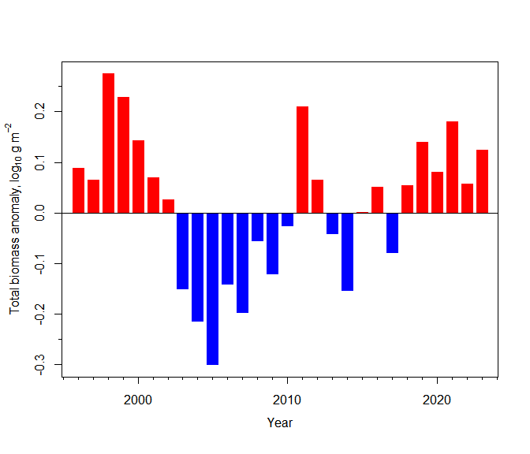

```r
plot(zooplankton_sog)
```

where the bars are automatically coloured red/blue for positive/negative anomalies. The plot defaults to showing the total biomass anomaly, and so updates Figure 2D of Perry et al. (2021), which included data only to 2018. Note that anomalies are now calculated compared to a climatology for the full time series (Young et al. 2023), whereas Perry et al. (2021) used the years 1996-2010 for their climatology, and extra historical samples have been processed (see `?zooplankton_sog`). Hence, numbers can differ when comparing new plots to older ones.